# Risk Factor Analysis

## Outcome Variable

**Outcome Variable:** ever_swasted

## Predictor Variables

**Intervention Variable:** mbmi

**Adjustment Set:**

unadjusted

## Stratifying Variables

The analysis was stratified on these variable(s):

- agecat
- studyid
- country

## Data Summary

| agecat | studyid | country | mbmi | ever_swasted | n_cell | n |
| --- | --- | --- | --- | --- | --- | --- |
| 0-24 months | ki0047075b-MAL-ED | BANGLADESH | Normal weight | 0 | 209 | 254 |
| 0-24 months | ki0047075b-MAL-ED | BANGLADESH | Normal weight | 1 | 13 | 254 |
| 0-24 months | ki0047075b-MAL-ED | BANGLADESH | Underweight | 0 | 24 | 254 |
| 0-24 months | ki0047075b-MAL-ED | BANGLADESH | Underweight | 1 | 8 | 254 |
| 0-24 months | ki0047075b-MAL-ED | BRAZIL | Normal weight | 0 | 207 | 221 |
| 0-24 months | ki0047075b-MAL-ED | BRAZIL | Normal weight | 1 | 4 | 221 |
| 0-24 months | ki0047075b-MAL-ED | BRAZIL | Underweight | 0 | 10 | 221 |
| 0-24 months | ki0047075b-MAL-ED | BRAZIL | Underweight | 1 | 0 | 221 |
| 0-24 months | ki0047075b-MAL-ED | INDIA | Normal weight | 0 | 177 | 242 |
| 0-24 months | ki0047075b-MAL-ED | INDIA | Normal weight | 1 | 16 | 242 |
| 0-24 months | ki0047075b-MAL-ED | INDIA | Underweight | 0 | 41 | 242 |
| 0-24 months | ki0047075b-MAL-ED | INDIA | Underweight | 1 | 8 | 242 |
| 0-24 months | ki0047075b-MAL-ED | NEPAL | Normal weight | 0 | 229 | 238 |
| 0-24 months | ki0047075b-MAL-ED | NEPAL | Normal weight | 1 | 9 | 238 |
| 0-24 months | ki0047075b-MAL-ED | NEPAL | Underweight | 0 | 0 | 238 |
| 0-24 months | ki0047075b-MAL-ED | NEPAL | Underweight | 1 | 0 | 238 |
| 0-24 months | ki0047075b-MAL-ED | PERU | Normal weight | 0 | 282 | 290 |
| 0-24 months | ki0047075b-MAL-ED | PERU | Normal weight | 1 | 3 | 290 |
| 0-24 months | ki0047075b-MAL-ED | PERU | Underweight | 0 | 5 | 290 |
| 0-24 months | ki0047075b-MAL-ED | PERU | Underweight | 1 | 0 | 290 |
| 0-24 months | ki0047075b-MAL-ED | SOUTH AFRICA | Normal weight | 0 | 249 | 270 |
| 0-24 months | ki0047075b-MAL-ED | SOUTH AFRICA | Normal weight | 1 | 13 | 270 |
| 0-24 months | ki0047075b-MAL-ED | SOUTH AFRICA | Underweight | 0 | 8 | 270 |
| 0-24 months | ki0047075b-MAL-ED | SOUTH AFRICA | Underweight | 1 | 0 | 270 |
| 0-24 months | ki0047075b-MAL-ED | TANZANIA, UNITED REPUBLIC OF | Normal weight | 0 | 236 | 256 |
| 0-24 months | ki0047075b-MAL-ED | TANZANIA, UNITED REPUBLIC OF | Normal weight | 1 | 6 | 256 |
| 0-24 months | ki0047075b-MAL-ED | TANZANIA, UNITED REPUBLIC OF | Underweight | 0 | 13 | 256 |
| 0-24 months | ki0047075b-MAL-ED | TANZANIA, UNITED REPUBLIC OF | Underweight | 1 | 1 | 256 |
| 0-24 months | ki1000304b-SAS-CompFeed | INDIA | Normal weight | 0 | 266 | 410 |
| 0-24 months | ki1000304b-SAS-CompFeed | INDIA | Normal weight | 1 | 35 | 410 |

[output cut: 158 more lines]

The following strata were considered:

- agecat: 0-24 months, studyid: ki0047075b-MAL-ED, country: BANGLADESH
- agecat: 0-24 months, studyid: ki0047075b-MAL-ED, country: BRAZIL
- agecat: 0-24 months, studyid: ki0047075b-MAL-ED, country: INDIA
- agecat: 0-24 months, studyid: ki0047075b-MAL-ED, country: NEPAL
- agecat: 0-24 months, studyid: ki0047075b-MAL-ED, country: PERU
- agecat: 0-24 months, studyid: ki0047075b-MAL-ED, country: SOUTH AFRICA
- agecat: 0-24 months, studyid: ki0047075b-MAL-ED, country: TANZANIA, UNITED REPUBLIC OF
- agecat: 0-24 months, studyid: ki1000304b-SAS-CompFeed, country: INDIA
- agecat: 0-24 months, studyid: ki1017093-NIH-Birth, country: BANGLADESH
- agecat: 0-24 months, studyid: ki1017093b-PROVIDE, country: BANGLADESH
- agecat: 0-24 months, studyid: ki1017093c-NIH-Crypto, country: BANGLADESH
- agecat: 0-24 months, studyid: ki1066203-TanzaniaChild2, country: TANZANIA, UNITED REPUBLIC OF
- agecat: 0-24 months, studyid: ki1112895-iLiNS-Zinc, country: BURKINA FASO
- agecat: 0-24 months, studyid: ki1119695-PROBIT, country: BELARUS
- agecat: 0-24 months, studyid: ki1126311-ZVITAMBO, country: ZIMBABWE
- agecat: 0-24 months, studyid: ki1148112-LCNI-5, country: MALAWI
- agecat: 0-6 months, studyid: ki0047075b-MAL-ED, country: BANGLADESH
- agecat: 0-6 months, studyid: ki0047075b-MAL-ED, country: BRAZIL
- agecat: 0-6 months, studyid: ki0047075b-MAL-ED, country: INDIA
- agecat: 0-6 months, studyid: ki0047075b-MAL-ED, country: NEPAL
- agecat: 0-6 months, studyid: ki0047075b-MAL-ED, country: PERU
- agecat: 0-6 months, studyid: ki0047075b-MAL-ED, country: SOUTH AFRICA
- agecat: 0-6 months, studyid: ki0047075b-MAL-ED, country: TANZANIA, UNITED REPUBLIC OF
- agecat: 0-6 months, studyid: ki1000304b-SAS-CompFeed, country: INDIA
- agecat: 0-6 months, studyid: ki1017093-NIH-Birth, country: BANGLADESH
- agecat: 0-6 months, studyid: ki1017093b-PROVIDE, country: BANGLADESH
- agecat: 0-6 months, studyid: ki1017093c-NIH-Crypto, country: BANGLADESH
- agecat: 0-6 months, studyid: ki1066203-TanzaniaChild2, country: TANZANIA, UNITED REPUBLIC OF
- agecat: 0-6 months, studyid: ki1119695-PROBIT, country: BELARUS
- agecat: 0-6 months, studyid: ki1126311-ZVITAMBO, country: ZIMBABWE
- agecat: 0-6 months, studyid: ki1148112-LCNI-5, country: MALAWI
- agecat: 6-24 months, studyid: ki0047075b-MAL-ED, country: BANGLADESH
- agecat: 6-24 months, studyid: ki0047075b-MAL-ED, country: BRAZIL
- agecat: 6-24 months, studyid: ki0047075b-MAL-ED, country: INDIA
- agecat: 6-24 months, studyid: ki0047075b-MAL-ED, country: NEPAL
- agecat: 6-24 months, studyid: ki0047075b-MAL-ED, country: PERU
- agecat: 6-24 months, studyid: ki0047075b-MAL-ED, country: SOUTH AFRICA
- agecat: 6-24 months, studyid: ki0047075b-MAL-ED, country: TANZANIA, UNITED REPUBLIC OF
- agecat: 6-24 months, studyid: ki1000304b-SAS-CompFeed, country: INDIA
- agecat: 6-24 months, studyid: ki1017093-NIH-Birth, country: BANGLADESH
- agecat: 6-24 months, studyid: ki1017093b-PROVIDE, country: BANGLADESH
- agecat: 6-24 months, studyid: ki1017093c-NIH-Crypto, country: BANGLADESH
- agecat: 6-24 months, studyid: ki1066203-TanzaniaChild2, country: TANZANIA, UNITED REPUBLIC OF
- agecat: 6-24 months, studyid: ki1112895-iLiNS-Zinc, country: BURKINA FASO
- agecat: 6-24 months, studyid: ki1119695-PROBIT, country: BELARUS
- agecat: 6-24 months, studyid: ki1126311-ZVITAMBO, country: ZIMBABWE
- agecat: 6-24 months, studyid: ki1148112-LCNI-5, country: MALAWI

### Dropped Strata

Some strata were dropped due to rare outcomes:

- agecat: 0-24 months, studyid: ki0047075b-MAL-ED, country: BRAZIL
- agecat: 0-24 months, studyid: ki0047075b-MAL-ED, country: NEPAL
- agecat: 0-24 months, studyid: ki0047075b-MAL-ED, country: PERU
- agecat: 0-24 months, studyid: ki0047075b-MAL-ED, country: SOUTH AFRICA
- agecat: 0-24 months, studyid: ki0047075b-MAL-ED, country: TANZANIA, UNITED REPUBLIC OF
- agecat: 0-24 months, studyid: ki1066203-TanzaniaChild2, country: TANZANIA, UNITED REPUBLIC OF
- agecat: 0-24 months, studyid: ki1148112-LCNI-5, country: MALAWI
- agecat: 0-6 months, studyid: ki0047075b-MAL-ED, country: BRAZIL
- agecat: 0-6 months, studyid: ki0047075b-MAL-ED, country: NEPAL
- agecat: 0-6 months, studyid: ki0047075b-MAL-ED, country: PERU
- agecat: 0-6 months, studyid: ki0047075b-MAL-ED, country: SOUTH AFRICA
- agecat: 0-6 months, studyid: ki0047075b-MAL-ED, country: TANZANIA, UNITED REPUBLIC OF
- agecat: 0-6 months, studyid: ki1066203-TanzaniaChild2, country: TANZANIA, UNITED REPUBLIC OF
- agecat: 0-6 months, studyid: ki1148112-LCNI-5, country: MALAWI
- agecat: 6-24 months, studyid: ki0047075b-MAL-ED, country: BANGLADESH
- agecat: 6-24 months, studyid: ki0047075b-MAL-ED, country: BRAZIL
- agecat: 6-24 months, studyid: ki0047075b-MAL-ED, country: INDIA
- agecat: 6-24 months, studyid: ki0047075b-MAL-ED, country: NEPAL
- agecat: 6-24 months, studyid: ki0047075b-MAL-ED, country: PERU
- agecat: 6-24 months, studyid: ki0047075b-MAL-ED, country: SOUTH AFRICA
- agecat: 6-24 months, studyid: ki0047075b-MAL-ED, country: TANZANIA, UNITED REPUBLIC OF
- agecat: 6-24 months, studyid: ki1017093b-PROVIDE, country: BANGLADESH
- agecat: 6-24 months, studyid: ki1066203-TanzaniaChild2, country: TANZANIA, UNITED REPUBLIC OF
- agecat: 6-24 months, studyid: ki1119695-PROBIT, country: BELARUS
- agecat: 6-24 months, studyid: ki1148112-LCNI-5, country: MALAWI

## Methods Detail

We’re interested in the causal parameters $E[Y_a]$ for all values of $a \in \mathcal{A}$. These parameters represent the mean outcome if, possibly contrary to fact, we intervened to set all units to have $A=a$. Under the randomization and positivity assumptions, these are identified by the statistical parameters $\psi_a=E_W[E_{Y|A,W}(Y|A=a,W)]$. In addition, we’re interested in the mean of $Y$, $E[Y]$ under no intervention (the observed mean). We will estimate these parameters by using SuperLearner to fit the relevant likelihood factors – $E_{Y|A,W}(Y|A=a,W)$ and $p(A=a|W)$, and then updating our likelihood fit using a joint TMLE.

For unadjusted analyses ($W=\{\}$), initial likelihoods were estimated using Lrnr_glm to estimate the simple $E(Y|A)$ and Lrnr_mean to estimate $p(A)$. For adjusted analyses, a small library containing Lrnr_glmnet, Lrnr_xgboost, and Lrnr_mean was used.

Having estimated these parameters, we will then use the delta method to estimate relative risks and attributable risks relative to a prespecified baseline level of $A$.

# Results Detail

## Results Plots

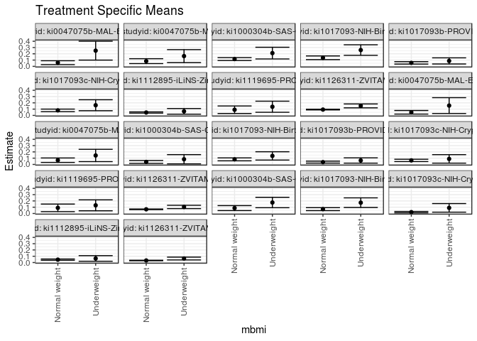

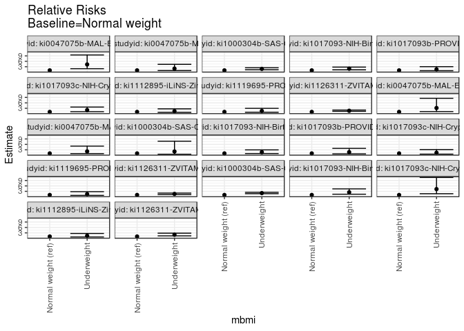

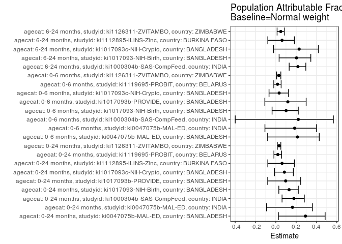

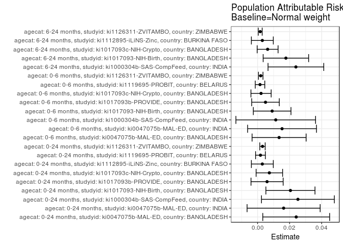

## Results Table

### Parameter: TSM

| agecat | studyid | country | intervention_level | baseline_level | estimate | ci_lower | ci_upper |
| --- | --- | --- | --- | --- | --- | --- | --- |
| 0-24 months | ki0047075b-MAL-ED | BANGLADESH | Normal weight | NA | 0.0585586 | 0.0276115 | 0.0895057 |
| 0-24 months | ki0047075b-MAL-ED | BANGLADESH | Underweight | NA | 0.2500000 | 0.0996753 | 0.4003247 |
| 0-24 months | ki0047075b-MAL-ED | INDIA | Normal weight | NA | 0.0829016 | 0.0439201 | 0.1218830 |
| 0-24 months | ki0047075b-MAL-ED | INDIA | Underweight | NA | 0.1632653 | 0.0595626 | 0.2669680 |
| 0-24 months | ki1000304b-SAS-CompFeed | INDIA | Normal weight | NA | 0.1162791 | 0.0932879 | 0.1392703 |
| 0-24 months | ki1000304b-SAS-CompFeed | INDIA | Underweight | NA | 0.2110092 | 0.1179380 | 0.3040804 |
| 0-24 months | ki1017093-NIH-Birth | BANGLADESH | Normal weight | NA | 0.1365385 | 0.1070030 | 0.1660739 |
| 0-24 months | ki1017093-NIH-Birth | BANGLADESH | Underweight | NA | 0.2596154 | 0.1752870 | 0.3439437 |
| 0-24 months | ki1017093b-PROVIDE | BANGLADESH | Normal weight | NA | 0.0553506 | 0.0360855 | 0.0746156 |
| 0-24 months | ki1017093b-PROVIDE | BANGLADESH | Underweight | NA | 0.0866142 | 0.0376597 | 0.1355687 |
| 0-24 months | ki1017093c-NIH-Crypto | BANGLADESH | Normal weight | NA | 0.0800582 | 0.0597515 | 0.1003650 |
| 0-24 months | ki1017093c-NIH-Crypto | BANGLADESH | Underweight | NA | 0.1617647 | 0.0741844 | 0.2493450 |
| 0-24 months | ki1112895-iLiNS-Zinc | BURKINA FASO | Normal weight | NA | 0.0458015 | 0.0359581 | 0.0556449 |
| 0-24 months | ki1112895-iLiNS-Zinc | BURKINA FASO | Underweight | NA | 0.0645161 | 0.0198013 | 0.1092310 |
| 0-24 months | ki1119695-PROBIT | BELARUS | Normal weight | NA | 0.0899068 | 0.0298072 | 0.1500065 |
| 0-24 months | ki1119695-PROBIT | BELARUS | Underweight | NA | 0.1377953 | 0.0495010 | 0.2260896 |
| 0-24 months | ki1126311-ZVITAMBO | ZIMBABWE | Normal weight | NA | 0.0927702 | 0.0868677 | 0.0986727 |
| 0-24 months | ki1126311-ZVITAMBO | ZIMBABWE | Underweight | NA | 0.1511628 | 0.1202541 | 0.1820714 |
| 0-6 months | ki0047075b-MAL-ED | BANGLADESH | Normal weight | NA | 0.0495495 | 0.0209465 | 0.0781526 |
| 0-6 months | ki0047075b-MAL-ED | BANGLADESH | Underweight | NA | 0.1562500 | 0.0301989 | 0.2823011 |
| 0-6 months | ki0047075b-MAL-ED | INDIA | Normal weight | NA | 0.0673575 | 0.0319236 | 0.1027914 |
| 0-6 months | ki0047075b-MAL-ED | INDIA | Underweight | NA | 0.1428571 | 0.0446763 | 0.2410380 |
| 0-6 months | ki1000304b-SAS-CompFeed | INDIA | Normal weight | NA | 0.0400000 | 0.0170477 | 0.0629523 |
| 0-6 months | ki1000304b-SAS-CompFeed | INDIA | Underweight | NA | 0.0825688 | 0.0088981 | 0.1562395 |
| 0-6 months | ki1017093-NIH-Birth | BANGLADESH | Normal weight | NA | 0.0809249 | 0.0574431 | 0.1044066 |
| 0-6 months | ki1017093-NIH-Birth | BANGLADESH | Underweight | NA | 0.1359223 | 0.0696853 | 0.2021593 |
| 0-6 months | ki1017093b-PROVIDE | BANGLADESH | Normal weight | NA | 0.0369004 | 0.0210177 | 0.0527831 |
| 0-6 months | ki1017093b-PROVIDE | BANGLADESH | Underweight | NA | 0.0629921 | 0.0207072 | 0.1052771 |
| 0-6 months | ki1017093c-NIH-Crypto | BANGLADESH | Normal weight | NA | 0.0640466 | 0.0457263 | 0.0823669 |
| 0-6 months | ki1017093c-NIH-Crypto | BANGLADESH | Underweight | NA | 0.0882353 | 0.0207757 | 0.1556949 |
| 0-6 months | ki1119695-PROBIT | BELARUS | Normal weight | NA | 0.0894410 | 0.0292809 | 0.1496010 |
| 0-6 months | ki1119695-PROBIT | BELARUS | Underweight | NA | 0.1299213 | 0.0426434 | 0.2171991 |
| 0-6 months | ki1126311-ZVITAMBO | ZIMBABWE | Normal weight | NA | 0.0662703 | 0.0612007 | 0.0713398 |
| 0-6 months | ki1126311-ZVITAMBO | ZIMBABWE | Underweight | NA | 0.1041257 | 0.0775910 | 0.1306604 |
| 6-24 months | ki1000304b-SAS-CompFeed | INDIA | Normal weight | NA | 0.0860215 | 0.0463993 | 0.1256437 |
| 6-24 months | ki1000304b-SAS-CompFeed | INDIA | Underweight | NA | 0.1747573 | 0.0918489 | 0.2576656 |
| 6-24 months | ki1017093-NIH-Birth | BANGLADESH | Normal weight | NA | 0.0691964 | 0.0456740 | 0.0927188 |
| 6-24 months | ki1017093-NIH-Birth | BANGLADESH | Underweight | NA | 0.1720430 | 0.0952661 | 0.2488199 |
| 6-24 months | ki1017093c-NIH-Crypto | BANGLADESH | Normal weight | NA | 0.0211161 | 0.0101649 | 0.0320673 |
| 6-24 months | ki1017093c-NIH-Crypto | BANGLADESH | Underweight | NA | 0.0895522 | 0.0211337 | 0.1579708 |
| 6-24 months | ki1112895-iLiNS-Zinc | BURKINA FASO | Normal weight | NA | 0.0458015 | 0.0359581 | 0.0556449 |
| 6-24 months | ki1112895-iLiNS-Zinc | BURKINA FASO | Underweight | NA | 0.0645161 | 0.0198013 | 0.1092310 |
| 6-24 months | ki1126311-ZVITAMBO | ZIMBABWE | Normal weight | NA | 0.0324611 | 0.0286020 | 0.0363203 |
| 6-24 months | ki1126311-ZVITAMBO | ZIMBABWE | Underweight | NA | 0.0634573 | 0.0411051 | 0.0858095 |

### Parameter: E(Y)

| agecat | studyid | country | intervention_level | baseline_level | estimate | ci_lower | ci_upper |
| --- | --- | --- | --- | --- | --- | --- | --- |
| 0-24 months | ki0047075b-MAL-ED | BANGLADESH | NA | NA | 0.0826772 | 0.0487426 | 0.1166117 |
| 0-24 months | ki0047075b-MAL-ED | INDIA | NA | NA | 0.0991736 | 0.0614374 | 0.1369097 |
| 0-24 months | ki1000304b-SAS-CompFeed | INDIA | NA | NA | 0.1414634 | 0.0976910 | 0.1852359 |
| 0-24 months | ki1017093-NIH-Birth | BANGLADESH | NA | NA | 0.1570513 | 0.1284803 | 0.1856223 |
| 0-24 months | ki1017093b-PROVIDE | BANGLADESH | NA | NA | 0.0612855 | 0.0430966 | 0.0794744 |
| 0-24 months | ki1017093c-NIH-Crypto | BANGLADESH | NA | NA | 0.0874172 | 0.0672569 | 0.1075775 |
| 0-24 months | ki1112895-iLiNS-Zinc | BURKINA FASO | NA | NA | 0.0487805 | 0.0359763 | 0.0615847 |
| 0-24 months | ki1119695-PROBIT | BELARUS | NA | NA | 0.0917239 | 0.0322246 | 0.1512233 |
| 0-24 months | ki1126311-ZVITAMBO | ZIMBABWE | NA | NA | 0.0958457 | 0.0900162 | 0.1016752 |
| 0-6 months | ki0047075b-MAL-ED | BANGLADESH | NA | NA | 0.0629921 | 0.0330555 | 0.0929287 |
| 0-6 months | ki0047075b-MAL-ED | INDIA | NA | NA | 0.0826446 | 0.0478818 | 0.1174075 |
| 0-6 months | ki1000304b-SAS-CompFeed | INDIA | NA | NA | 0.0513447 | 0.0345770 | 0.0681125 |
| 0-6 months | ki1017093-NIH-Birth | BANGLADESH | NA | NA | 0.0900322 | 0.0675202 | 0.1125442 |
| 0-6 months | ki1017093b-PROVIDE | BANGLADESH | NA | NA | 0.0418535 | 0.0266676 | 0.0570395 |
| 0-6 months | ki1017093c-NIH-Crypto | BANGLADESH | NA | NA | 0.0662252 | 0.0484753 | 0.0839750 |
| 0-6 months | ki1119695-PROBIT | BELARUS | NA | NA | 0.0909770 | 0.0313462 | 0.1506078 |
| 0-6 months | ki1126311-ZVITAMBO | ZIMBABWE | NA | NA | 0.0682447 | 0.0632414 | 0.0732480 |
| 6-24 months | ki1000304b-SAS-CompFeed | INDIA | NA | NA | 0.1099476 | 0.0559115 | 0.1639838 |
| 6-24 months | ki1017093-NIH-Birth | BANGLADESH | NA | NA | 0.0868762 | 0.0631205 | 0.1106318 |
| 6-24 months | ki1017093c-NIH-Crypto | BANGLADESH | NA | NA | 0.0273973 | 0.0155476 | 0.0392469 |
| 6-24 months | ki1112895-iLiNS-Zinc | BURKINA FASO | NA | NA | 0.0487805 | 0.0359763 | 0.0615847 |
| 6-24 months | ki1126311-ZVITAMBO | ZIMBABWE | NA | NA | 0.0341161 | 0.0302702 | 0.0379621 |

### Parameter: RR

| agecat | studyid | country | intervention_level | baseline_level | estimate | ci_lower | ci_upper |
| --- | --- | --- | --- | --- | --- | --- | --- |
| 0-24 months | ki0047075b-MAL-ED | BANGLADESH | Normal weight | Normal weight | 1.000000 | 1.0000000 | 1.000000 |
| 0-24 months | ki0047075b-MAL-ED | BANGLADESH | Underweight | Normal weight | 4.269231 | 1.9172672 | 9.506412 |
| 0-24 months | ki0047075b-MAL-ED | INDIA | Normal weight | Normal weight | 1.000000 | 1.0000000 | 1.000000 |
| 0-24 months | ki0047075b-MAL-ED | INDIA | Underweight | Normal weight | 1.969388 | 0.8935400 | 4.340587 |
| 0-24 months | ki1000304b-SAS-CompFeed | INDIA | Normal weight | Normal weight | 1.000000 | 1.0000000 | 1.000000 |
| 0-24 months | ki1000304b-SAS-CompFeed | INDIA | Underweight | Normal weight | 1.814679 | 1.3451058 | 2.448179 |
| 0-24 months | ki1017093-NIH-Birth | BANGLADESH | Normal weight | Normal weight | 1.000000 | 1.0000000 | 1.000000 |
| 0-24 months | ki1017093-NIH-Birth | BANGLADESH | Underweight | Normal weight | 1.901409 | 1.2870303 | 2.809067 |
| 0-24 months | ki1017093b-PROVIDE | BANGLADESH | Normal weight | Normal weight | 1.000000 | 1.0000000 | 1.000000 |
| 0-24 months | ki1017093b-PROVIDE | BANGLADESH | Underweight | Normal weight | 1.564829 | 0.8057378 | 3.039067 |
| 0-24 months | ki1017093c-NIH-Crypto | BANGLADESH | Normal weight | Normal weight | 1.000000 | 1.0000000 | 1.000000 |
| 0-24 months | ki1017093c-NIH-Crypto | BANGLADESH | Underweight | Normal weight | 2.020588 | 1.1112781 | 3.673947 |
| 0-24 months | ki1112895-iLiNS-Zinc | BURKINA FASO | Normal weight | Normal weight | 1.000000 | 1.0000000 | 1.000000 |
| 0-24 months | ki1112895-iLiNS-Zinc | BURKINA FASO | Underweight | Normal weight | 1.408602 | 0.7417226 | 2.675070 |
| 0-24 months | ki1119695-PROBIT | BELARUS | Normal weight | Normal weight | 1.000000 | 1.0000000 | 1.000000 |
| 0-24 months | ki1119695-PROBIT | BELARUS | Underweight | Normal weight | 1.532645 | 0.7922879 | 2.964833 |
| 0-24 months | ki1126311-ZVITAMBO | ZIMBABWE | Normal weight | Normal weight | 1.000000 | 1.0000000 | 1.000000 |
| 0-24 months | ki1126311-ZVITAMBO | ZIMBABWE | Underweight | Normal weight | 1.629433 | 1.3153322 | 2.018541 |
| 0-6 months | ki0047075b-MAL-ED | BANGLADESH | Normal weight | Normal weight | 1.000000 | 1.0000000 | 1.000000 |
| 0-6 months | ki0047075b-MAL-ED | BANGLADESH | Underweight | Normal weight | 3.153409 | 1.1694063 | 8.503450 |
| 0-6 months | ki0047075b-MAL-ED | INDIA | Normal weight | Normal weight | 1.000000 | 1.0000000 | 1.000000 |
| 0-6 months | ki0047075b-MAL-ED | INDIA | Underweight | Normal weight | 2.120879 | 0.8925630 | 5.039564 |
| 0-6 months | ki1000304b-SAS-CompFeed | INDIA | Normal weight | Normal weight | 1.000000 | 1.0000000 | 1.000000 |
| 0-6 months | ki1000304b-SAS-CompFeed | INDIA | Underweight | Normal weight | 2.064220 | 0.5489885 | 7.761556 |
| 0-6 months | ki1017093-NIH-Birth | BANGLADESH | Normal weight | Normal weight | 1.000000 | 1.0000000 | 1.000000 |
| 0-6 months | ki1017093-NIH-Birth | BANGLADESH | Underweight | Normal weight | 1.679612 | 0.9525624 | 2.961586 |
| 0-6 months | ki1017093b-PROVIDE | BANGLADESH | Normal weight | Normal weight | 1.000000 | 1.0000000 | 1.000000 |
| 0-6 months | ki1017093b-PROVIDE | BANGLADESH | Underweight | Normal weight | 1.707087 | 0.7690289 | 3.789382 |
| 0-6 months | ki1017093c-NIH-Crypto | BANGLADESH | Normal weight | Normal weight | 1.000000 | 1.0000000 | 1.000000 |
| 0-6 months | ki1017093c-NIH-Crypto | BANGLADESH | Underweight | Normal weight | 1.377674 | 0.6090195 | 3.116460 |
| 0-6 months | ki1119695-PROBIT | BELARUS | Normal weight | Normal weight | 1.000000 | 1.0000000 | 1.000000 |
| 0-6 months | ki1119695-PROBIT | BELARUS | Underweight | Normal weight | 1.452592 | 0.7514597 | 2.807899 |
| 0-6 months | ki1126311-ZVITAMBO | ZIMBABWE | Normal weight | Normal weight | 1.000000 | 1.0000000 | 1.000000 |
| 0-6 months | ki1126311-ZVITAMBO | ZIMBABWE | Underweight | Normal weight | 1.571228 | 1.2041697 | 2.050175 |
| 6-24 months | ki1000304b-SAS-CompFeed | INDIA | Normal weight | Normal weight | 1.000000 | 1.0000000 | 1.000000 |
| 6-24 months | ki1000304b-SAS-CompFeed | INDIA | Underweight | Normal weight | 2.031553 | 1.6858285 | 2.448179 |
| 6-24 months | ki1017093-NIH-Birth | BANGLADESH | Normal weight | Normal weight | 1.000000 | 1.0000000 | 1.000000 |
| 6-24 months | ki1017093-NIH-Birth | BANGLADESH | Underweight | Normal weight | 2.486299 | 1.4187907 | 4.357008 |
| 6-24 months | ki1017093c-NIH-Crypto | BANGLADESH | Normal weight | Normal weight | 1.000000 | 1.0000000 | 1.000000 |
| 6-24 months | ki1017093c-NIH-Crypto | BANGLADESH | Underweight | Normal weight | 4.240938 | 1.6843541 | 10.678014 |
| 6-24 months | ki1112895-iLiNS-Zinc | BURKINA FASO | Normal weight | Normal weight | 1.000000 | 1.0000000 | 1.000000 |
| 6-24 months | ki1112895-iLiNS-Zinc | BURKINA FASO | Underweight | Normal weight | 1.408602 | 0.7417226 | 2.675070 |
| 6-24 months | ki1126311-ZVITAMBO | ZIMBABWE | Normal weight | Normal weight | 1.000000 | 1.0000000 | 1.000000 |
| 6-24 months | ki1126311-ZVITAMBO | ZIMBABWE | Underweight | Normal weight | 1.954872 | 1.3479207 | 2.835125 |

### Parameter: PAR

| agecat | studyid | country | intervention_level | baseline_level | estimate | ci_lower | ci_upper |
| --- | --- | --- | --- | --- | --- | --- | --- |
| 0-24 months | ki0047075b-MAL-ED | BANGLADESH | Normal weight | NA | 0.0241186 | 0.0032585 | 0.0449787 |
| 0-24 months | ki0047075b-MAL-ED | INDIA | Normal weight | NA | 0.0162720 | -0.0065276 | 0.0390716 |
| 0-24 months | ki1000304b-SAS-CompFeed | INDIA | Normal weight | NA | 0.0251843 | 0.0024533 | 0.0479154 |
| 0-24 months | ki1017093-NIH-Birth | BANGLADESH | Normal weight | NA | 0.0205128 | 0.0051916 | 0.0358340 |
| 0-24 months | ki1017093b-PROVIDE | BANGLADESH | Normal weight | NA | 0.0059349 | -0.0040953 | 0.0159652 |
| 0-24 months | ki1017093c-NIH-Crypto | BANGLADESH | Normal weight | NA | 0.0073590 | -0.0009086 | 0.0156266 |
| 0-24 months | ki1112895-iLiNS-Zinc | BURKINA FASO | Normal weight | NA | 0.0029790 | -0.0038647 | 0.0098226 |
| 0-24 months | ki1119695-PROBIT | BELARUS | Normal weight | NA | 0.0018171 | -0.0012462 | 0.0048804 |
| 0-24 months | ki1126311-ZVITAMBO | ZIMBABWE | Normal weight | NA | 0.0030755 | 0.0013981 | 0.0047528 |
| 0-6 months | ki0047075b-MAL-ED | BANGLADESH | Normal weight | NA | 0.0134426 | -0.0034159 | 0.0303011 |
| 0-6 months | ki0047075b-MAL-ED | INDIA | Normal weight | NA | 0.0152871 | -0.0061918 | 0.0367661 |
| 0-6 months | ki1000304b-SAS-CompFeed | INDIA | Normal weight | NA | 0.0113447 | -0.0135098 | 0.0361993 |
| 0-6 months | ki1017093-NIH-Birth | BANGLADESH | Normal weight | NA | 0.0091073 | -0.0026406 | 0.0208552 |
| 0-6 months | ki1017093b-PROVIDE | BANGLADESH | Normal weight | NA | 0.0049531 | -0.0036567 | 0.0135629 |
| 0-6 months | ki1017093c-NIH-Crypto | BANGLADESH | Normal weight | NA | 0.0021786 | -0.0041367 | 0.0084939 |
| 0-6 months | ki1119695-PROBIT | BELARUS | Normal weight | NA | 0.0015360 | -0.0014333 | 0.0045053 |
| 0-6 months | ki1126311-ZVITAMBO | ZIMBABWE | Normal weight | NA | 0.0019744 | 0.0005556 | 0.0033933 |
| 6-24 months | ki1000304b-SAS-CompFeed | INDIA | Normal weight | NA | 0.0239261 | 0.0065389 | 0.0413134 |
| 6-24 months | ki1017093-NIH-Birth | BANGLADESH | Normal weight | NA | 0.0176797 | 0.0034933 | 0.0318662 |
| 6-24 months | ki1017093c-NIH-Crypto | BANGLADESH | Normal weight | NA | 0.0062811 | -0.0002381 | 0.0128003 |
| 6-24 months | ki1112895-iLiNS-Zinc | BURKINA FASO | Normal weight | NA | 0.0029790 | -0.0038647 | 0.0098226 |
| 6-24 months | ki1126311-ZVITAMBO | ZIMBABWE | Normal weight | NA | 0.0016550 | 0.0004349 | 0.0028751 |

### Parameter: PAF

| agecat | studyid | country | intervention_level | baseline_level | estimate | ci_lower | ci_upper |
| --- | --- | --- | --- | --- | --- | --- | --- |
| 0-24 months | ki0047075b-MAL-ED | BANGLADESH | Normal weight | NA | 0.2917203 | 0.0252675 | 0.4853356 |
| 0-24 months | ki0047075b-MAL-ED | INDIA | Normal weight | NA | 0.1640760 | -0.0913332 | 0.3597107 |
| 0-24 months | ki1000304b-SAS-CompFeed | INDIA | Normal weight | NA | 0.1780273 | 0.0612924 | 0.2802453 |
| 0-24 months | ki1017093-NIH-Birth | BANGLADESH | Normal weight | NA | 0.1306122 | 0.0295812 | 0.2211249 |
| 0-24 months | ki1017093b-PROVIDE | BANGLADESH | Normal weight | NA | 0.0968410 | -0.0799060 | 0.2446600 |
| 0-24 months | ki1017093c-NIH-Crypto | BANGLADESH | Normal weight | NA | 0.0841824 | -0.0136139 | 0.1725431 |
| 0-24 months | ki1112895-iLiNS-Zinc | BURKINA FASO | Normal weight | NA | 0.0610687 | -0.0788764 | 0.1828610 |
| 0-24 months | ki1119695-PROBIT | BELARUS | Normal weight | NA | 0.0198105 | -0.0187090 | 0.0568735 |
| 0-24 months | ki1126311-ZVITAMBO | ZIMBABWE | Normal weight | NA | 0.0320880 | 0.0145165 | 0.0493461 |
| 0-6 months | ki0047075b-MAL-ED | BANGLADESH | Normal weight | NA | 0.2134009 | -0.0806932 | 0.4274618 |
| 0-6 months | ki0047075b-MAL-ED | INDIA | Normal weight | NA | 0.1849741 | -0.1072848 | 0.4000936 |
| 0-6 months | ki1000304b-SAS-CompFeed | INDIA | Normal weight | NA | 0.2209524 | -0.3996528 | 0.5663816 |
| 0-6 months | ki1017093-NIH-Birth | BANGLADESH | Normal weight | NA | 0.1011561 | -0.0369306 | 0.2208539 |
| 0-6 months | ki1017093b-PROVIDE | BANGLADESH | Normal weight | NA | 0.1183448 | -0.1080833 | 0.2985040 |
| 0-6 months | ki1017093c-NIH-Crypto | BANGLADESH | Normal weight | NA | 0.0328967 | -0.0669351 | 0.1233873 |
| 0-6 months | ki1119695-PROBIT | BELARUS | Normal weight | NA | 0.0168834 | -0.0198275 | 0.0522728 |
| 0-6 months | ki1126311-ZVITAMBO | ZIMBABWE | Normal weight | NA | 0.0289316 | 0.0080116 | 0.0494104 |
| 6-24 months | ki1000304b-SAS-CompFeed | INDIA | Normal weight | NA | 0.2176139 | 0.1313053 | 0.2953474 |
| 6-24 months | ki1017093-NIH-Birth | BANGLADESH | Normal weight | NA | 0.2035049 | 0.0323440 | 0.3443906 |
| 6-24 months | ki1017093c-NIH-Crypto | BANGLADESH | Normal weight | NA | 0.2292609 | -0.0217519 | 0.4186077 |
| 6-24 months | ki1112895-iLiNS-Zinc | BURKINA FASO | Normal weight | NA | 0.0610687 | -0.0788764 | 0.1828610 |
| 6-24 months | ki1126311-ZVITAMBO | ZIMBABWE | Normal weight | NA | 0.0485112 | 0.0124746 | 0.0832327 |